# Gamma Regression

## Introduction

- Recall the general linear model,

$$y = \beta_0 + \beta_1 x_1 + ... + \beta_k x_k + \varepsilon$$

- Until this week, we focused on applying the normal distribution to our model.
- What happens when we have a response variable that is continuous but skewed right?
  - In this lecture, we will introduce gamma regression.

## Gamma Regression

- Consider the gamma distribution,

$$f(y|\mu, \gamma) = \frac{1}{\Gamma(\gamma) \left( \frac{\mu}{\gamma} \right)^\gamma} y^{\gamma-1} \exp\left\{ \frac{-y \gamma}{\mu} \right\}$$

- where: $y > 0$, $\mu > 0$, $\gamma > 0$, and $\Gamma(\cdot)$ is the [Gamma function](https://en.wikipedia.org/wiki/Gamma_function)
- Note that the distribution is defined by the shape parameters, $\gamma$, and the scale parameter, $\mu/\gamma$.

## Gamma Regression

- Why shouldn’t we use the normal distribution here?
  - When we apply the normal distribution, we assume that the outcome (response) can take any value. i.e.,
    $$y \in (-\infty, \infty)$$
  - In this case, our continuous response variable is bounded between 0 and $\infty$. i.e.,
    $$y \in (0, \infty)$$
- The gamma distribution is appropriate for modeling continuous, positive, right-skewed data.
  - I have most often used it in time-to-event analysis.

## Gamma Distribution

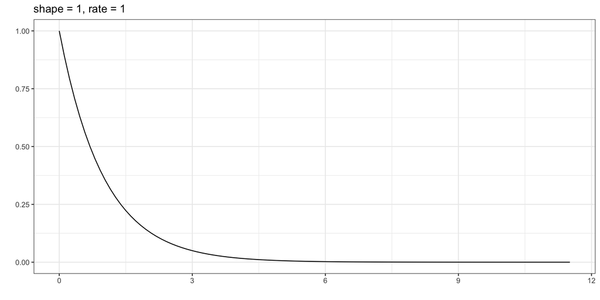

## Gamma Distribution

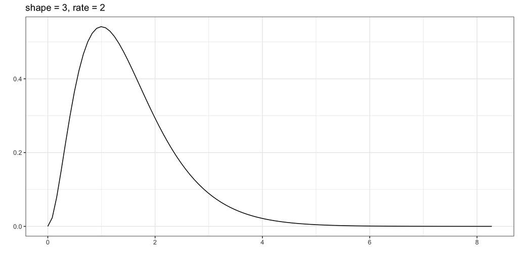

## Gamma Distribution

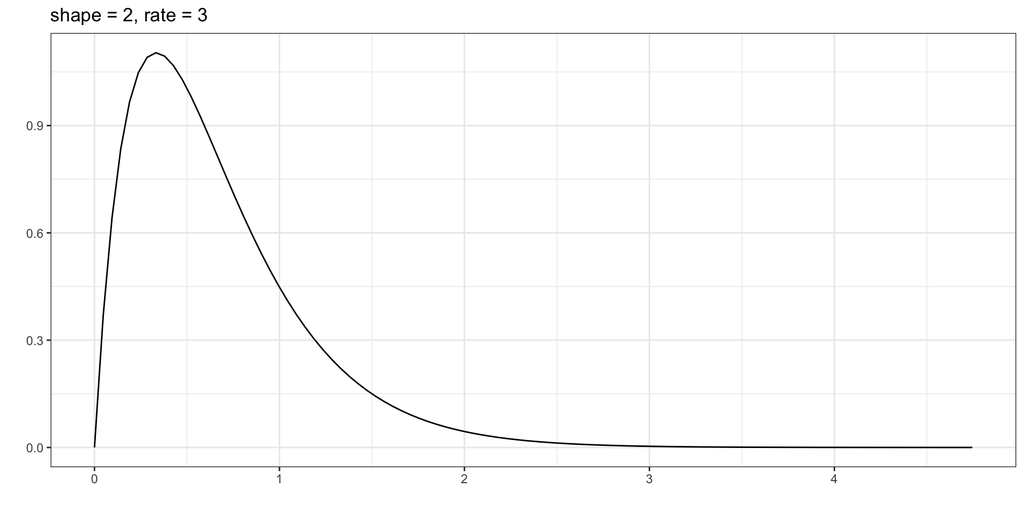

## Gamma Distribution

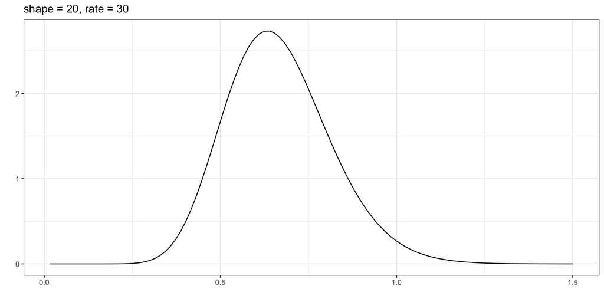

## Data Management

- Note that the support for the gamma distribution is $(0, \infty)$.
  - Exactly 0 is not included in the support.
- What does that mean for us?
  - If we have exact 0s in our response variable, we **will transform** it slightly to fall within $(0, \infty)$.

$$y_{\text{new}} = y + 0.01$$

- Note! There are models to accommodate exact 0s (e.g., hurdle models), but we will not cover them in this course.

## Gamma Regression (R)

- We will use the `glm()` function to perform Gamma regression,

```r
m <- glm(y ~ x_1 + ... + x_k,
         data = dataset_name,
         family = Gamma(link = "log"))
```

- Note the new-to-us piece of syntax: `link = "log"` attached to `family`.
  - This specifies that we are using the log link function.
  - Technically we used the identity link with normal regression. It is the default, but we could have specified `family = gaussian(link = "identity")`.

## Lecture Example Set Up

- We are working with the Magic Kingdom operations team. For a sample of ride observations taken throughout several days, WDW has recorded:
  - wait_time: posted standby wait time (minutes)
  - temp_f: outdoor temperature (°F)
  - crowd_index: a 1–10 index summarizing park busyness
  - ride_type: “family”, “dark”, or “thrill”

## Lecture Example Set Up

- Pulling in the data,

```r
mk_wait <- read_csv("https://raw.githubusercontent.com/samanthaseals/SDSII/refs/heads/main/files/data/lectures/W4_wait_times.csv")
mk_wait %>% head()
```

| temp_f | crowd_index | ride_type | wait_time |
| --- | --- | --- | --- |
| 96 | 10.0 | family | 19 |
| 92 | 4.8 | dark | 28 |
| 94 | 6.5 | dark | 25 |
| 83 | 5.8 | thrill | 51 |
| 83 | 8.8 | family | 20 |
| 78 | 5.5 | family | 19 |

## Gamma Regression: Example

- Let’s check the outcome of our data,

```r
mk_wait %>% ggplot(aes(x = wait_time)) +
  geom_histogram(binwidth = 5, color = "black", fill = "lightblue") +
  labs(x = "Wait Time", y = "Count") +
  theme_bw()
```

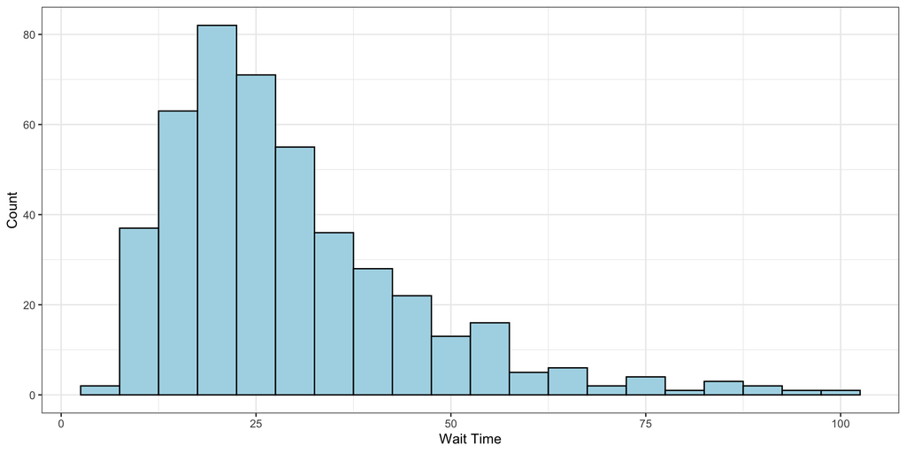

## Gamma Regression: Example

- Let’s further examine the outcome,

```r
mk_wait %>% summarize(min = min(wait_time),
                      median = median(wait_time),
                      max = max(wait_time))
```

| min | median | max |
| --- | --- | --- |
| 6 | 25 | 99 |

- No data management is needed – there are no 0 minute wait times in this dataset.

## Gamma Regression: Example

- Let’s model how expected wait time changes with weather, crowds, and ride type.

```r
m1 <- glm(wait_time ~ temp_f + crowd_index + ride_type,
         data = mk_wait,
         family = Gamma(link = "log"))
m1 %>% tidy()
```

| term | estimate | std.error | statistic | p.value |
| --- | --- | --- | --- | --- |
| (Intercept) | 1.2815640 | 0.294042792 | 4.358427 | 1.628520e-05 |
| temp_f | 0.0149594 | 0.003244209 | 4.611109 | 5.242028e-06 |
| crowd_index | 0.1094566 | 0.010934510 | 10.010193 | 2.074258e-21 |
| ride_typefamily | -0.1904717 | 0.045333020 | -4.201611 | 3.203677e-05 |
| ride_typethrill | 0.4291482 | 0.047961523 | 8.947761 | 9.859001e-18 |

## Gamma Regression: Example

- Let’s model how expected wait time changes with weather, crowds, and ride type.

```r
m1 %>% coefficients()
```

```
    (Intercept)          temp_f     crowd_index ride_typefamily ride_typethrill
      1.2815640       0.0149594       0.1094566      -0.1904717       0.4291482
```

## Interpreting the Model

- Uh oh. We are now modeling ln(*y*) and not *y* directly…
  - We need to “undo” the ln() so that we can discuss the results in the original units of *y*
- We will transform the coefficients:

$$\begin{align*}
\ln(\hat{y}) &= \hat{\beta}_0 + \hat{\beta}_1 x_1 + \hat{\beta}_2 x_2 + ... \hat{\beta}_k x_k \\
\hat{y} &= \exp\left\{\hat{\beta}_0 + \hat{\beta}_1 x_1 + \hat{\beta}_2 x_2 + ... \hat{\beta}_kx_k \right\} \\
\hat{y} &= e^{\hat{\beta}_0} e^{\hat{\beta}_1x_1} e^{\hat{\beta}_2 x_2} \cdot \cdot \cdot e^{\hat{\beta}_k x_k}
\end{align*}$$

- These are *multiplicative* effects, as compared to the *additive* effects we saw under the normal distribution.
- **Note**: Please do not write your model as a function of $\hat{y}$ – the above is only to demonstrate the multiplicative effect.

## Interpreting the Model

- This multiplicative effect is called the incident rate ratio.
  - For a 1 unit increase in $x_i$, we expect $\hat{y}$ to be *multiplied* by $e^{\hat{\beta}_i}$
- Let’s think about multiplicative effects:
  - When $e^{\hat{\beta}_i} > 1$, (i.e., an increase in $\hat{y}$).
  - When $0 < e^{\hat{\beta}_i} < 1$, (i.e., a decrease in $\hat{y}$).
  - When $e^{\hat{\beta}_i} = 1$, (i.e., no change in $\hat{y}$).
- Examples:
  - if $e^{\hat{\beta}_1} = 1.2$, then for a 1 unit increase in $x_1$, we expect $\hat{y}$ to be *multiplied* by 1.2 (i.e., a 20% increase in $\hat{y}$)
  - If $e^{\hat{\beta}_2} = 0.8$, then for a 1 unit increase in $x_2$, we expect $\hat{y}$ to be *multiplied* by 0.8 (i.e., a 20% decrease in $\hat{y}$)

## Statistical Inference (R)

- Our approach to determining significance remains the same.
  - For continuous and binary predictors, we can use the Wald test ($z$-test from `tidy()`).
  - For omnibus tests, we can use the likelihood ratio test (LRT).
    - Significance of regression line (full/reduced LRT).
    - Significance of categorical predictors with $c \ge 3$ levels (`car::Anova(type = 3)` or full/reduced LRT).
    - Interaction terms with categorical predictors with $c \ge 3$ levels (`car::Anova(type = 3)` or full/reduced LRT).

## Statistical Inference: Example

- Let’s first check for the significance of the regression line,

```r
m1_full <- glm(wait_time ~ temp_f + crowd_index + ride_type, data = mk_wait, family = Gamma(link = "log"))
m1_reduced <- glm(wait_time ~ 1, data = mk_wait, family = Gamma(link = "log"))
anova(m1_reduced, m1_full, test = "LRT")
```

|  | Resid. Df | Resid. Dev | Df | Deviance | Pr(>Chi) |
| --- | --- | --- | --- | --- | --- |
| 1 | 449 | 121.02322 | NA | NA | NA |
| 2 | 445 | 72.18459 | 4 | 48.83864 | 1.772798e-63 |

- Yes, this is a significant regression line ($p < 0.001$).
  - At least one of the slopes is non-zero.

## Statistical Inference: Example

- Now, we can look at individual predictors of wait time,

```r
m1 %>% tidy() %>% select(term, estimate, p.value)
```

| term | estimate | p.value |
| --- | --- | --- |
| (Intercept) | 1.2815640 | 1.628520e-05 |
| temp_f | 0.0149594 | 5.242028e-06 |
| crowd_index | 0.1094566 | 2.074258e-21 |
| ride_typefamily | -0.1904717 | 3.203677e-05 |
| ride_typethrill | 0.4291482 | 9.859001e-18 |

- Temperature is a significant predictor ($p < 0.001$).
- Crowd index is a significant predictor ($p < 0.001$).
- Ride type…?

## Statistical Inference: Example

- Now, we can look at individual predictors of wait time,

```r
m1 %>% car::Anova(type = 3)
```

|  | LR Chisq | Df | Pr(>Chisq) |
| --- | --- | --- | --- |
| temp_f | 21.85514 | 1 | 2.940284e-06 |
| crowd_index | 99.58374 | 1 | 1.880415e-23 |
| ride_type | 179.03435 | 2 | 1.327958e-39 |

- Temperature is a significant predictor ($p < 0.001$).
- Crowd index is a significant predictor ($p < 0.001$).
- Ride type is a significant predictor ($p < 0.001$).

## Statistical Inference: Example

- Returning to our `tidy()` results for ride type,

```r
m1 %>% tidy() %>% filter(term %in% c("ride_typefamily", "ride_typethrill")) %>% select(term, estimate, p.value)
```

| term | estimate | p.value |
| --- | --- | --- |
| ride_typefamily | -0.1904717 | 3.203677e-05 |
| ride_typethrill | 0.4291482 | 9.859001e-18 |

- Family rides have significantly lower wait times than dark rides ($p < 0.001$).
- Thrill rides have significantly higher wait times than dark rides ($p < 0.001$).

## Wrap Up

- In this lecture, we have introduced gamma regression.
  - Gamma regression is appropriate for continuous, positive, right-skewed data.
- We introduced modeling with the log-link and how that affects interpretations.
  - We interpret coefficients as multiplicative effects on the response variable.
- In the next lecture, we will review visualizing gamma regression.